# ETC5512

## ETC5512

### Introduction to web scraping

Lecturer: *Kate Saunders*

Department of Econometrics and Business Statistics

- ETC5512.Clayton-x@monash.edu
- Wild Caught Data
- wcd.numbat.space

## Journey so far

**Journey**

- Weeks 1 - 2: Introducing you to open data and data collection
- Weeks 4 - 7: Different data case studies (cakes!!!)
- Weeks 8 - 9: Data ethics and data privacy
- Week 10: **Today two goals:** Show you web-scraping & have some fun!

## Motivation

> The most important thing I’ve ever done for learning R is to paradoxically stop “learning” (e.g. classes and problem sets) and start doing. Take a problem you have at work or school or a dataset you find interesting and get to work. Then write it up and post on githib or a blog. https://t.co/9aQZJRrlFK

> — We are R-Ladies (@WeAreRLadies) [March 25, 2019](https://twitter.com/WeAreRLadies/status/1110229736956067840?ref_src=twsrc%5Etfw)

## After my PhD - I wanted to read more!

[video not shown]

**Question**

How should I choose what to read?

I want to read different perspectives and broaden my world view.

## Picking from lists

[figure not shown]

**Is this a good approach?**

Am I actually reading diversely?

Suspicious this might be very biased sample.

## My approach

**Got a question - Am I reading diversely**

- Now I’m going to try to answer it!
- One option is to find an open data set, another is I create my own data set for analysis using web scraping
- I’m going to take a [book list of best sellers](https://en.wikipedia.org/wiki/List_of_best-selling_books) and analyse the nationalities of different authors
- Seems simple right - Let’s see how this works out!

## Today’s lecture

**What we’ll cover**

- Cover the basics of navigating around webpages
- Learn about when its appropriate to scrape data
- Also discover the challenges of working with data from the web

**Coding Perspective:**

- Learn how to read data from a webpage into R
- See some examples of wrapping code in functions
- Learn about automating a scraper

# html basics

## Go to a webpage

[Link to the wikipedia page for a famous Australian author](https://en.wikipedia.org/wiki/Tim_Winton)

[figure not shown]

## View html code in Chrome

- Right click the part of the page you want
- Select inpsect

[figure not shown]

## Html code

- Brings up the html code
- Highlights the piece of html code related to your click
- Hover over html code to see other features of the web page

[figure not shown]

## Inpsect button

- Similarly, click the top left button in the side panel
- Explore related features of the webpage and html code

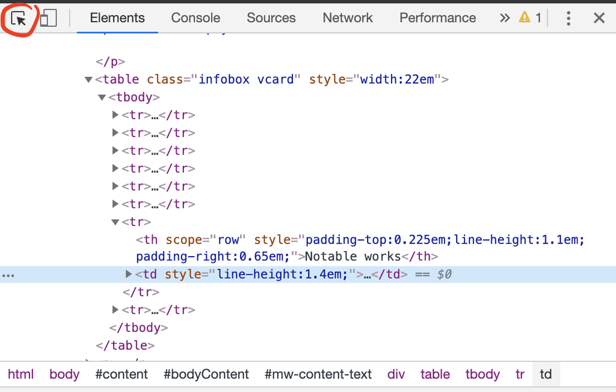

## Basic html types

By browsing you observe the basic **structure** of html webpages

Opening and closing [tags](https://www.w3schools.com/tags/) are used to wrap around content and define its purpose and appearance on a webpage.

e.g. < tag > some random text < /tag >

**Basic tag types**

- div - division or section
- p - paragraph elements
- h - heading
- table - Table
- td - table data
- a - anchor for a hyperlink

## Breakout Session

**Try it yourself time**

- Pick an author and find their wikipedia page
- Explore the structure of the webpage
- Look at the different html tags

# Web scraping in R

## R Packages

There are lots of packages in R that can be used for web scraping.

**Two main R packages**

[`rvest`](https://rvest.tidyverse.org/articles/rvest.html) *Focus today*

- Great for those new to web scraping
- Works best for static web pages
- Similar coding syntax to tidyverse packages

[`RSelenium`](https://cran.r-project.org/web/packages/RSelenium/vignettes/basics.html)

- Better for more complex tasks
- Use it when you have web pages that load dynamically (pop ups, list menus, drop downs etc)

## Read a webpage

```r
library(tidyverse)
library(rvest)
author_url <- "https://en.wikipedia.org/wiki/Tim_Winton"
wiki_data <- read_html(author_url) # Read the webpage into R
wiki_data
```

```
{html_document}
<html class="client-nojs vector-feature-language-in-header-enabled vector-feature-language-in-main-menu-disabled vector-feature-language-in-main-page-header-disabled vector-feature-page-tools-pinned-disabled vector-feature-toc-pinned-clientpref-1 vector-feature-main-menu-pinned-disabled vector-featu…
[1] <head>\n<meta http-equiv="Content-Type" content="text/html; charset=UTF-8 ...
[2] <body class="skin--responsive skin-vector skin-vector-search-vue mediawik ...
```

## How to scrape a table - html_table()

So we can read data from the website into R, but we need the data in a form we can use.

```r
all_tables <- wiki_data |>
  html_table(header = FALSE) #Get all tables on the webpage

length(all_tables)
```

```
[1] 5
```

```r
infocard = all_tables |>
  pluck(1) #pluck out the first item in the list
infocard
```

```
# A tibble: 9 × 2
  X1                                             X2
  <chr>                                          <chr>
1 Tim WintonAO                                   Tim WintonAO
2 Winton at the launch of Breath in London, 2008 Winton at the launch of Breath…
3 Born                                           Timothy John Winton4 August 19…
4 Occupation                                     Novelist
5 Nationality                                    Australian
6 Period                                         1982–present
7 Genre                                          Literature, children's, non-fi…
8 Notable works                                  Cloudstreet Dirt Music Breath …
9 Notable awards                                 Miles Franklin  1984, 1992, 20…
```

## Other approaches - html_elements()

```r
infocard <- wiki_data |>
 html_elements("table") |> # get all tables
 html_table(header = FALSE) |>
 pluck(1)

infocard
```

```
# A tibble: 9 × 2
  X1                                             X2
  <chr>                                          <chr>
1 Tim WintonAO                                   Tim WintonAO
2 Winton at the launch of Breath in London, 2008 Winton at the launch of Breath…
3 Born                                           Timothy John Winton4 August 19…
4 Occupation                                     Novelist
5 Nationality                                    Australian
6 Period                                         1982–present
7 Genre                                          Literature, children's, non-fi…
8 Notable works                                  Cloudstreet Dirt Music Breath …
9 Notable awards                                 Miles Franklin  1984, 1992, 20…
```

## Other approaches - html_element()

Similarly to other functions in the tidyverse there are functions to return all matches, or just one match.

```r
infocard <- wiki_data |>
 html_element("table") |> # get the first table
 html_table(header = FALSE)

infocard
```

```
# A tibble: 9 × 2
  X1                                             X2
  <chr>                                          <chr>
1 Tim WintonAO                                   Tim WintonAO
2 Winton at the launch of Breath in London, 2008 Winton at the launch of Breath…
3 Born                                           Timothy John Winton4 August 19…
4 Occupation                                     Novelist
5 Nationality                                    Australian
6 Period                                         1982–present
7 Genre                                          Literature, children's, non-fi…
8 Notable works                                  Cloudstreet Dirt Music Breath …
9 Notable awards                                 Miles Franklin  1984, 1992, 20…
```

## Using classes

We can also match specific elements on a web page using classes.

`<table class="infobox vcard">`

*Notice in the code we use dots instead of spaces in the class string.*

```r
infocard <- wiki_data |>
    html_element(".infobox.vcard") |> # matches the specific table class
    html_table(header = FALSE)
infocard
```

```
# A tibble: 9 × 2
  X1                                             X2
  <chr>                                          <chr>
1 Tim WintonAO                                   Tim WintonAO
2 Winton at the launch of Breath in London, 2008 Winton at the launch of Breath…
3 Born                                           Timothy John Winton4 August 19…
4 Occupation                                     Novelist
5 Nationality                                    Australian
6 Period                                         1982–present
7 Genre                                          Literature, children's, non-fi…
8 Notable works                                  Cloudstreet Dirt Music Breath …
9 Notable awards                                 Miles Franklin  1984, 1992, 20…
```

## Get the Nationality

One more step - Need to get the nationality from the table.

This just requires some basic data wrangling.

```r
author_nationality = infocard |>
  rename(Category = X1, Response = X2) |>
  filter(Category == "Nationality") |>
  pull(Response)
author_nationality
```

```
[1] "Australian"
```

**Real challenge**

Can we generalise?

## Breakout Session

**Try it yourself time**

- For the author you picked, download their infocard into R
- Can you get their nationality from the infocard?
- At your table discuss any challenges you face

## Let’s try a different author

Wikipedia page for author Jane Austen

[figure not shown]

## Let’s get that infocard

```r
author_url <- "https://en.wikipedia.org/wiki/Jane_Austen"
wiki_data <- read_html(author_url)

infocard <- wiki_data |>
  html_element(".infobox.vcard") |>
  html_table(header = FALSE)

author_nationality = infocard |>
  rename(Category = X1, Response = X2) |>
  filter(Category == "Nationality") |>
  pull(Response)

author_nationality # :( oh oh
```

```
character(0)
```

## Blocker!!!

**Warning**

**No nationality** category in Jane Austen’s infocard

The infocards on wikipedia do not have a standard format!

This is a real barrier automation

**Tip**

But her nationality is in the webpage text.  
I could just scrape her nationality from there.

## Try another way

```r
para_data <- wiki_data |>
  html_elements("p") # get all the paragraphs
head(para_data)
```

```
{xml_nodeset (6)}
[1] <p class="mw-empty-elt">\n\n\n\n</p>
[2] <p><b>Jane Austen</b> (<span class="rt-commentedText nowrap"><span class= ...
[3] <p>Austen's plots often explore the dependence of women on marriage for t ...
[4] <p>Austen wrote major novels before the age of 22, but she was not publis ...
[5] <p>Since her death Austen's novels have rarely been out of print. A signi ...
[6] <p>Her novels have been frequently adapted into film and television. Nota ...
```

**Caution**

But where exactly do we find her nationality in all this text?

Let’s go back to exploring the webpage.

## Get the text - html_text()

```r
text_data <- para_data |>
  pluck(2) |> # get the second paragraph
  html_text() # convert the html paragraph to text
head(text_data)
```

```
[1] "Jane Austen (/ˈɒstɪn, ˈɔːstɪn/ OST-in, AW-stin; 16 December 1775 – 18 July 1817) was an English writer known primarily for her six novels, which implicitly interpret, critique, and comment on the English landed gentry at the end of the 18th century.\n"
```

There are more ways we can navigate around a web page, some are very useful in combination with string handling.

## Xpath Example

- Right click html code, copy, copy Xpath

[figure not shown]

## Using an Xpath

```r
para_xpath = '//*[@id="mw-content-text"]/div/p[2]'

text_data <- wiki_data |>
  html_element(xpath = para_xpath) |>
  html_text()
text_data
```

```
[1] "Jane Austen (/ˈɒstɪn, ˈɔːstɪn/ OST-in, AW-stin; 16 December 1775 – 18 July 1817) was an English writer known primarily for her six novels, which implicitly interpret, critique, and comment on the English landed gentry at the end of the 18th century.\n"
```

## CSS Selector Example

- Right click html code, copy, copy selector

[figure not shown]

## Using CSS ID

```r
para_css = "#mw-content-text > div.mw-content-ltr.mw-parser-output > p:nth-child(5)"

text_data <- wiki_data |>
  html_element(css = para_css) |>
  html_text()
text_data
```

```
[1] "Jane Austen (/ˈɒstɪn, ˈɔːstɪn/ OST-in, AW-stin; 16 December 1775 – 18 July 1817) was an English writer known primarily for her six novels, which implicitly interpret, critique, and comment on the English landed gentry at the end of the 18th century.\n"
```

## Back to getting the nationality

Once we have our text need to do some text analysis - could use `str_count`

```r
possible_nationalities <- c("Australian", "Chinese", "Mexican", "English", "Ethiopian")

# Count how many time these appear in the text
count_values = str_count(text_data, possible_nationalities)

# Get the matching nationalities
possible_nationalities[count_values > 0]
```

```
[1] "English"
```

**Caution**

- What do you think of my solution?
- Any guesses why I didn’t use `str_match`?

# Automation

## Web scraping Applications

**Examples**

In business analytics web there are many scraping applications. Some include:

- **Competitive Intelligence**: Monitoring competitors’ pricing, product offerings, and promotions in real-time
- **Market Research**: Gathering customer reviews, sentiment analysis, and identifying trends
- **Price Optimisation**: Analysing price points across markets to inform dynamic pricing strategies
- **Financial Analysis**: Extracting economic indicators, stock performance data, and financial news for investment decisions

## Why automate?

Web scrapers are used to collect data **regularly, with no to minimal manual effort and typically at scale**.

**Tip**

- Regular Timing: Setting up scrapers to run daily, weekly, or hourly
- Simple Notifications: Getting emails or messages when important data changes
- Saving Data Automatically: Storing collected data in spreadsheets or databases
- Error Handling: Making sure scrapers continue working when websites change

## Functions for automation

Let’s automate.

Any code that gets repeated can be written as function.

Here is a simple example of a function that adds two numbers.

```r
add_two_numbers <-function(num1, num2){
  number_sum = num1 + num2
  return(number_sum)
}
```

## Error handling

Key to automation is carefully handling any errors. A common function for this is in R is `tryCatch()`

```r
ans1 = tryCatch(add_two_numbers(1, 1),
         error = function(e){return(NA)})
ans1
```

```
[1] 2
```

```r
ans2 = tryCatch(add_two_numbers("a", 1),
         error = function(e){ print(e); return(NA)})
```

```
<simpleError in num1 + num2: non-numeric argument to binary operator>
```

```r
ans2
```

```
[1] NA
```

```r
ans3 = tryCatch(add_two_numbers(x, 1),
         error = function(e){ print(e); return("Your code didn't work")})
```

```
<simpleError in eval(expr, envir): object 'x' not found>
```

```r
ans3
```

```
[1] "Your code didn't work"
```

## Ethical scraping

**Important**

Just because you can scrape - doesn’t mean you should!

As with any data analytics you must to think about ethics!

**Think about**

- Check the terms and conditions and terms of use
- Look for a data licence
- Review the robots.txt file for the website (e.g. https://www.example.com/robots.txt).
- Be considerate of the volume of queries and query rate limit - see `polite` package in R.
- Am I respecting people’s data privacy?

## Breakout Session

**Try it yourself time**

Is it okay to automate data scraping from:

- Wikipedia?
- [Australian Bureau of Meteorology](http://www.bom.gov.au/)?
- realestate.com.au?

# Back to my author example

## Pseudo code

**Planning ahead**

- Before you start a project it can be a good idea to plan it out
- Pseudo code is the simplified, informal description of an algorithm
- Pseudo code can contain words and coding syntax
- Use pseudo code to identify coding building blocks / individual steps, and to identify potential problems or blockers.

## For my project

**Pseudo code**

1. Read the wiki webpage about an author.
2. Get the info card.
3. Try to get the nationality from the infocard.
4. If no nationality or infocard, I want to find the first paragraphs containing text.
5. Guess the nationality from the text.  
   *Going to need nationalities for matching.*
6. Bring the above all together in a single function so I can automatatically iterate over a list of authors.  
   *Going to need my list of author web pages.*

**Also need to think about how I handle any errors!**

## Wrap my code chunks

1. Want a function to read the wiki webpage about an author

```r
Read_wiki_page <- function(author_url){
  wiki_data <- read_html(author_url)
  return(wiki_data)
}
```

## More wrapping of code chunks

2. Want a function to read the info card.

```r
Get_wiki_infocard <- function(wiki_data){
  infocard <- wiki_data |>
    html_element(".infobox.vcard") |>
    html_table(header = FALSE)
  return(infocard)
}
```

## More wrapping of code chunks

3. Want a function to get the nationality from the infocard

```r
Get_nationality_from_infocard <- function(infocard){
  nationality <- infocard |>
    rename(Category = X1, Response = X2) |>
    filter(Category == "Nationality") |>
    pull(Response)
  return(nationality)
}
```

## More wrapping of code chunks

4. Need a function to find the first html paragraph containing text *(Remember I didn’t say this was a good idea - we are learning!)*

```r
Get_first_text <- function(wiki_data){

  paragraph_data <- wiki_data |>
    html_elements("p")

  i = 1
  no_text = TRUE
  while(no_text){

    text_data <- paragraph_data |>
      purrr::pluck(i) |>
      html_text()

    check_text = gsub("\\s+", "", text_data)

    if(check_text == ""){
      # keep searching
      i = i + 1
    }else{
      # end the while loop
      no_text = FALSE
    }
  }
  return(text_data)
}
```

## More wrapping of code chunks

5. Need another function to “guess” the nationality from the text

```r
Guess_nationality_from_text <- function(text_data, possible_nationalities){

  num_matches <- str_count(text_data, possible_nationalities)

  prob_matches <- num_matches/sum(num_matches)

  i = which(prob_matches > 0)
  if(length(i) == 1){

    prob_nationality = possible_nationalities[i]

    return(prob_nationality)

  }else if(length(i) > 0){

    warning(paste(c("More than one match for the nationality:",
                    possible_nationalities[i], "\n"), collapse = " "))

    likely_nationality = which.max(prob_matches)

    prob_nationality = possible_nationalities[likely_nationality]

    return(prob_nationality)

  }else{

    return("No nationality matched")

  }

}
```

## More wrapping of code chunks

6. One function that brings that all together

```r
Query_nationality_from_wiki <- function(author_url, possible_nationalities){

  wiki_data <- Read_wiki_page(author_url)

  infocard <- Get_wiki_infocard(wiki_data)

  if(is.null(infocard)){

    # missing infocard - get nationality from text
    first_paragraph <- Get_first_text(wiki_data)

    nationality <- Guess_nationality_from_text(first_paragraph,
                                               possible_nationalities)

    return(nationality)

  }

  if(any(infocard[,1] == "Nationality")){

    # info card exists and has nationality
    nationality <- Get_nationality_from_infocard(infocard)

  }else{

    # no nationality in infocard - find nationality in text
    text_data <- Get_first_text(wiki_data)
    nationality <- Guess_nationality_from_text(text_data,
                                               possible_nationalities)

  }

  return(nationality)

}
```

## Test our code

```r
author_url = "https://en.wikipedia.org/wiki/Tim_Winton"
Query_nationality_from_wiki(author_url, c("English", "British", "Australian"))
```

```
[1] "Australian"
```

```r
author_url <- "https://en.wikipedia.org/wiki/Jane_Austen"
Query_nationality_from_wiki(author_url , c("English", "British", "Australian"))
```

```
[1] "English"
```

## Do some error handling

```r
Wrapper_nationality_query <- function(author_url, possible_nationalities){

  author_nationality = tryCatch(
    Query_nationality_from_wiki(author_url, possible_nationalities),
    error = function(e){print("Encountered an error; returning an error code 99999"); return(99999)})

  return(author_nationality)

}
```

## Test our code - try to break it

```r
author_url <- "not are real web address"
Wrapper_nationality_query(author_url , c("English", "British", "Australian"))
```

```
[1] "Encountered an error; returning an error code 99999"
```

```
[1] 99999
```

```r
author_url <- "https://en.wikipedia.org/wiki/Jane_Austen"
Wrapper_nationality_query(author_url , c("Chinese", "Indian", "Thai"))
```

```
[1] "No nationality matched"
```

# Results

## Data

**Data Dictionary**

- `author_name` (character string): Author name .
- `author_links` (character string): Url for the author name scraped from the [wikipedia bestseller list](https://en.wikipedia.org/wiki/List_of_best-selling_books). Some of these links are invalid and will partially match `NA` or `character(0)`.
- `author_nationality` (character string): The nationality is either taken directly from the author’s infocard on the `author_link`, or is guessed from corresponding text. If guessed, this is the nationality string that appears most often, where nationalities are matched to the list provided by the [UK government webpage](https://www.gov.uk/government/publications/nationalities/list-of-nationalities) .

```r
author_df = read_csv("data/author_df.csv")
head(author_df)
```

```
# A tibble: 6 × 3
  author_name              author_links                              nationality
  <chr>                    <chr>                                     <chr>
1 Charles Dickens          https://en.wikipedia.org/wiki/Charles_Di… English
2 Antoine de Saint-Exupéry https://en.wikipedia.org/wiki/Antoine_de… French
3 Paulo Coelho             https://en.wikipedia.org/wiki/Paulo_Coel… Brazilian
4 J. K. Rowling            https://en.wikipedia.org/wiki/J._K._Rowl… British
5 Agatha Christie          https://en.wikipedia.org/wiki/Agatha_Chr… English
6 Cao Xueqin               https://en.wikipedia.org/wiki/Cao_Xueqin  Chinese
```

## Code to pull it all together

```r
author_df$author_nationality = NA
for(i in 1:nrow(author_df)){

  author_url = author_df$author_links[i]
  author_df$nationality[i] = Wrapper_nationality_query(author_url = author_url,
                            possible_nationalities = nationalities_data)
  print(paste(i, author_df$author_name[i], author_df$nationality[i]))

}
```

Here `nationalities_data` is from the UK government website.

## Not very diverse

Imperfect analysis, but the result is clear. Heavy bias towards America and the UK.

```r
author_df = read_csv("data/author_df.csv")
print(paste("Total bestsellers:", nrow(author_df)))
```

```
[1] "Total bestsellers: 293"
```

```r
author_df |>
  count(nationality) |>
  arrange(desc(n)) |>
  mutate(nationality = if_else(nationality == "99999", "Webpage error", nationality))
```

```
# A tibble: 41 × 2
   nationality                n
   <chr>                  <int>
 1 American                 112
 2 Webpage error             32
 3 British                   27
 4 English                   24
 5 Japanese                  18
 6 No nationality matched    11
 7 French                     6
 8 Russian                    6
 9 German                     5
10 Swedish                    5
# ℹ 31 more rows
```

## Code to get nationality data

Scrape a list of nationalities from the UK Government

```r
nationalities_url = "https://www.gov.uk/government/publications/nationalities/list-of-nationalities"

nationalities_data = read_html(nationalities_url) |>
  html_elements("td") |>
  html_text(trim = TRUE)

not_empty = (nationalities_data != "")
nationalities_data = nationalities_data[not_empty]

nationalities_data
```

```
  [1] "Afghan"                            "Albanian"
  [3] "Algerian"                          "American"
  [5] "Andorran"                          "Angolan"
  [7] "Anguillan"                         "Citizen of Antigua and Barbuda"
  [9] "Argentine"                         "Armenian"
 [11] "Australian"                        "Austrian"
 [13] "Azerbaijani"                       "Bahamian"
 [15] "Bahraini"                          "Bangladeshi"
 [17] "Barbadian"                         "Belarusian"
 [19] "Belgian"                           "Belizean"
 [21] "Beninese"                          "Bermudian"
 [23] "Bhutanese"                         "Bolivian"
 [25] "Citizen of Bosnia and Herzegovina" "Botswanan"
 [27] "Brazilian"                         "British"
 [29] "British Virgin Islander"           "Bruneian"
```

[output cut: 98 more lines]

## Code to get author webpages from bestellers list

```r
Get_url_for_author <- function(author_name, scraped_table){

  search_str = paste0("a[title = '", author_name, "']")

  matching_link = tryCatch(
    scraped_table |>
      html_elements(search_str) |>
      html_attr("href"),
    error = function(e) { NA })

  return(matching_link)

}

Get_url_from_html_table <- function(scraped_table){

  if(is.list(scraped_table)) scraped_table = scraped_table |> pluck(1)

  # get the html table entries
  table_entries = scraped_table |>
    html_elements("td")

  # make the table a data frame in R
  table_df = scraped_table |>
    html_table()
  author_vec = table_df$`Author(s)`

  # get the table dimensions
  table_dim = table_df |>
    dim()
  nrows = table_dim[1]
  ncols = table_dim[2]

  # the authors are in the second row, so get the cell indexes
  cell_indexes = seq(2, nrows*ncols, by = ncols)
  if(nrows*ncols == length(table_entries)){

    author_links = table_entries[cell_indexes] |>
      html_element("a") |>
      html_attr("href")

  }else{

  # however, some tables aren't standard for
  # for this we need a different function
  author_links = sapply(author_vec, Get_url_for_author, scraped_table)

  }

  author_links = paste0("https://en.wikipedia.org", author_links)
  author_df = data.frame(author_name = author_vec, author_links)

  return(author_df)

}

## Code to scrape the best sellers webpage

bestsellers_url <- "https://en.wikipedia.org/wiki/List_of_best-selling_books"
wiki_bestseller_tables = read_html(bestsellers_url) |>
  html_elements("table.wikitable")

warning("Hard code to avoid unwanted tables - don't want the dictionary!")
wiki_bestseller_tables_relevant = wiki_bestseller_tables[1:9]

author_df = NULL
for(i in 1:length(wiki_bestseller_tables_relevant)){
  result = Get_url_from_html_table(wiki_bestseller_tables_relevant[i])
  author_df = bind_rows(author_df, result)
}

author_df$author_links
```

```
  [1] "https://en.wikipedia.org/wiki/Charles_Dickens"
  [2] "https://en.wikipedia.org/wiki/Antoine_de_Saint-Exup%C3%A9ry"
  [3] "https://en.wikipedia.org/wiki/Paulo_Coelho"
  [4] "https://en.wikipedia.org/wiki/J._K._Rowling"
  [5] "https://en.wikipedia.org/wiki/Agatha_Christie"
  [6] "https://en.wikipedia.org/wiki/Cao_Xueqin"
  [7] "https://en.wikipedia.org/wiki/J._R._R._Tolkien"
  [8] "https://en.wikipedia.org/wiki/Lewis_Carroll"
  [9] "https://en.wikipedia.org/wiki/H._Rider_Haggard"
 [10] "https://en.wikipedia.org/wiki/Dan_Brown"
 [11] "https://en.wikipedia.org/wiki/J._K._Rowling"
 [12] "https://en.wikipedia.org/wiki/J._D._Salinger"
 [13] "https://en.wikipedia.org/wiki/J._K._Rowling"
 [14] "https://en.wikipedia.org/wiki/J._K._Rowling"
 [15] "https://en.wikipedia.org/wiki/J._K._Rowling"
```

[output cut: 289 more lines]

# What have we learnt

## A Few thoughts

**Reflection**

- Many ways to approach this problem  
  *eg. RSelenium, LLMs, APIs*
- Here we used the standard `rvest` toolbox
- Analysis was not perfect - the inconsistent webpage format was a real challenge!
- Also not ideal to be guessing nationalities from text
- But **we don’t need to approach a problem perfectly to learn** - break stuff, create errors, try and fail!

**Motivation**

We often learn best by picking a question we are passionate about and having some fun!

## A few thoughts ctd.

For assignment 4 I will ask you to think about writing your own open data case study. You will build upon the case studies we have done in case, but you may want to supplement your analysis with data you web scrape or other existing open data sets.

**Caution**

I showed you this example, because I wanted you to know:

1. Sometimes simple questions can be difficult to answer
2. It’s important to evaluate whether you data is fit for purpose early on
3. It’s good to check the logic of your approach by writing pseudo code
4. Even in projects that are fun there are aspects of data ethics to consider!

## Summary

**What we’ve learnt**

- Learnt how to navigate around a web page
- Learnt different ways to scrape data using the `rvest` package
- Learnt about important ethical considerations when web scraping
- Also wrote our first pseudo code
- Covered the basics about automation using functions
- Practiced some basic error handling
- Hopefully also had fun!